# Machine learning on Human activity Recognition: Weight Lifting Exercises

ISSEPELA

## Summary

This work is part of the machine learning Coursera Course This document about Human Activity Recognition describes the use of a machine learning algorithm on a dataset available online containing information collected by different accelerometers weared by 6 persons (on the belt, forearm, arm, and dumbell) while performing weight lifting in different way. The objective is to identify the movement.

cit: Velloso, E.; Bulling, A.; Gellersen, H.; Ugulino, W.; Fuks, H. Qualitative Activity Recognition of Weight Lifting Exercises. Proceedings of 4th International Conference in Cooperation with SIGCHI (Augmented Human 13) . Stuttgart, Germany: ACM SIGCHI, 2013. [Read more](http://groupware.les.inf.puc-rio.br/har#ixzz3mqgGqLDw)

## Background:

Six young health participants were asked to perform one set of 10 repetitions of the Unilateral Dumbbell Biceps Curl in five different fashions: exactly according to the specification (Class A), throwing the elbows to the front (Class B), lifting the dumbbell only halfway (Class C), lowering the dumbbell only halfway (Class D) and throwing the hips to the front (Class E).Class A corresponds to the specified execution of the exercise, while the other 4 classes correspond to common mistakes

## Data loading and cleansing

The dataset is available online: https://d396qusza40orc.cloudfront.net/predmachlearn/pml-training.csv  
-After having downloaded into the current working directory it must be loaded into R.  
-As there are lot of NA values, all the columns in which NA values are more than 50% are filtered out.  
-Also the first columns with the header of the measure (ID, name, date..) are removed.  
-Check for near zero covariate or near zero variance givesnegative result.

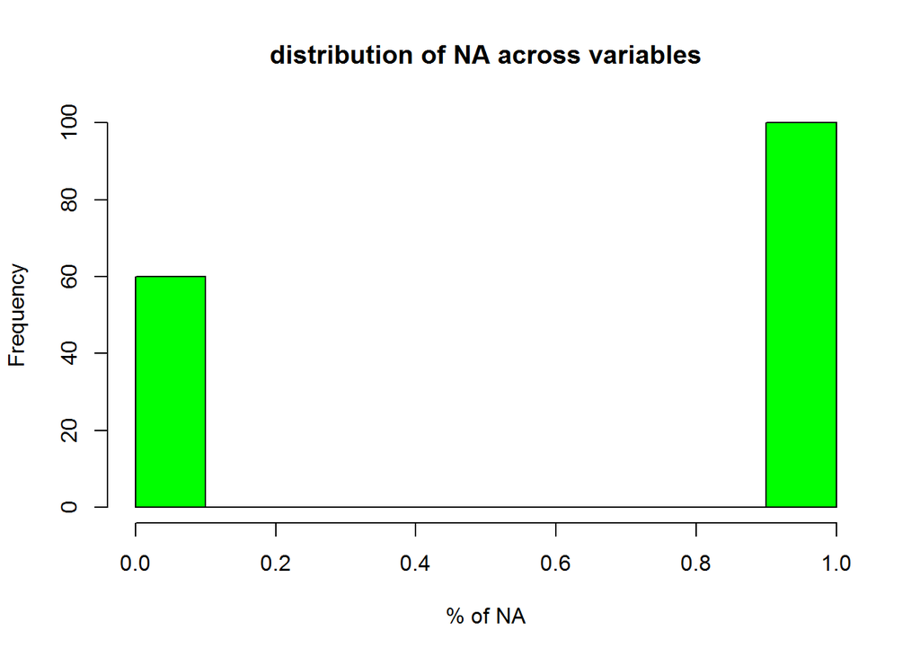

```r
library(caret);library('corrplot')
#load data
trainingDS<-read.csv("pml-training.csv",na.strings = c("#DIV/0!","NA"))
#distribution of NA
hist(colSums(is.na(trainingDS))/nrow(trainingDS),xlab="% of NA",main="distribution of NA across variables",col="green")
```

```r
#removing variables with mre than 50% NA
trainingDS <- trainingDS[, colSums(is.na(trainingDS)) < nrow(trainingDS)/2]
#removing first columns
trainingDS <- trainingDS[, -(1:7)]
#test for near zero variance
nsv<-nearZeroVar(trainingDS,saveMetrics = TRUE)
table(nsv$nzv,nsv$zeroVar)
```

```
##
##         FALSE
##   FALSE    53
```

Here is the list of predictors (plus the classe that we want to predict):

```r
names(trainingDS)
```

```
##  [1] "roll_belt"            "pitch_belt"           "yaw_belt"
##  [4] "total_accel_belt"     "gyros_belt_x"         "gyros_belt_y"
##  [7] "gyros_belt_z"         "accel_belt_x"         "accel_belt_y"
## [10] "accel_belt_z"         "magnet_belt_x"        "magnet_belt_y"
## [13] "magnet_belt_z"        "roll_arm"             "pitch_arm"
## [16] "yaw_arm"              "total_accel_arm"      "gyros_arm_x"
## [19] "gyros_arm_y"          "gyros_arm_z"          "accel_arm_x"
## [22] "accel_arm_y"          "accel_arm_z"          "magnet_arm_x"
## [25] "magnet_arm_y"         "magnet_arm_z"         "roll_dumbbell"
## [28] "pitch_dumbbell"       "yaw_dumbbell"         "total_accel_dumbbell"
## [31] "gyros_dumbbell_x"     "gyros_dumbbell_y"     "gyros_dumbbell_z"
## [34] "accel_dumbbell_x"     "accel_dumbbell_y"     "accel_dumbbell_z"
## [37] "magnet_dumbbell_x"    "magnet_dumbbell_y"    "magnet_dumbbell_z"
## [40] "roll_forearm"         "pitch_forearm"        "yaw_forearm"
## [43] "total_accel_forearm"  "gyros_forearm_x"      "gyros_forearm_y"
## [46] "gyros_forearm_z"      "accel_forearm_x"      "accel_forearm_y"
## [49] "accel_forearm_z"      "magnet_forearm_x"     "magnet_forearm_y"
## [52] "magnet_forearm_z"     "classe"
```

## Exploratory data analysis on predictors

We have 52 predictors, divided in 4 groups of 13 given by the accelerometers of the 4 different devices.  
A simple plot of one group of variables (given by the device on the belt) colored by class give the impression that there is not a simple relation between the variables and the class. For this reason, linear model and generalized linear model will not be taken into consideration.

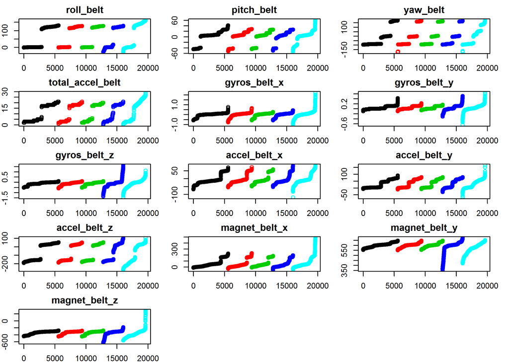

```r
par("mar"=c(2,2,2,2))
par(mfrow = c(5, 3))
col <- grep("belt", names(trainingDS))
for (i in 1:length(col)){
    trainingDS<-trainingDS[ order(trainingDS[,53], trainingDS[,col[i]]), ]
    plot(trainingDS[, col[i]], col = trainingDS$classe, main = names(trainingDS)[col[i]])
}
```

The variables have some degree of correlation, expecially inside the same device.  
For this reason a preprocess of Principal Component Analysis will be perfomed before training our prediction models.

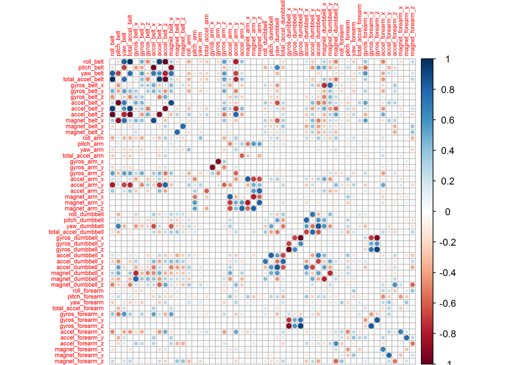

```r
M<-(cor(trainingDS[,-53]))
diag(M)<-0
corrplot(M, cl.lim=c(-1,1),tl.cex=.5)
```

## Machine learning

### Trainig and probing dataset preparation

The dataset will be split in 2 in order for cross validation and out of the sample error estimation.  
For reproducebility a seed fill be fixed

```r
set.seed(1111)
inTrain<-createDataPartition(y=trainingDS$classe,p=.75,list=FALSE)
training<-trainingDS[inTrain,]
probing<-trainingDS[-inTrain,]
dim(training);dim(probing)
```

```
## [1] 14718    53
## [1] 4904   53
```

### Model training

For comparison, 3 different training methods will be tested  
First we will try predicting with trees

```r
system.time(modFit_rpart<-train(classe~.,method="rpart",data=training,preProcess=c("center","scale","pca")))
```

```
##    user  system elapsed
##   72.88    0.69   74.37
```

```r
modFit_rpart
## CART
##
## 14718 samples
##    52 predictor
##     5 classes: 'A', 'B', 'C', 'D', 'E'
##
## Pre-processing: centered, scaled, principal component signal extraction
## Resampling: Bootstrapped (25 reps)
## Summary of sample sizes: 14718, 14718, 14718, 14718, 14718, 14718, ...
## Resampling results across tuning parameters:
##
##   cp          Accuracy   Kappa      Accuracy SD  Kappa SD
##   0.03151998  0.3825638  0.1758090  0.03434969   0.06222093
##   0.06069812  0.3551431  0.1257538  0.02852075   0.05149912
##   0.11516187  0.2837717  0.0000000  0.00512526   0.00000000
##
## Accuracy was used to select the optimal model using  the largest value.
## The final value used for the model was cp = 0.03151998.
```

the in-sample error gives a poor accuracy of 0.38

The second model is random forest

```r
system.time(modFit_rf<-train(classe~.,method="rf",data=training,preProcess=c("center","scale","pca")))
```

```
##    user  system elapsed
## 3301.31   19.40 3332.25
```

```r
modFit_rf
## Random Forest
##
## 14718 samples
##    52 predictor
##     5 classes: 'A', 'B', 'C', 'D', 'E'
##
## Pre-processing: centered, scaled, principal component signal extraction
## Resampling: Bootstrapped (25 reps)
## Summary of sample sizes: 14718, 14718, 14718, 14718, 14718, 14718, ...
## Resampling results across tuning parameters:
##
##   mtry  Accuracy   Kappa      Accuracy SD  Kappa SD
##    2    0.9645018  0.9551012  0.002874545  0.003618778
##   27    0.9486177  0.9350100  0.005914001  0.007481343
##   52    0.9483651  0.9346906  0.005563645  0.007036942
##
## Accuracy was used to select the optimal model using  the largest value.
## The final value used for the model was mtry = 2.
```

The third model is Naive Bayes

```r
system.time(modFit_nb<-train(classe~.,method="nb",data=training,preProcess=c("center","scale","pca")))
```

```
##    user  system elapsed
## 1168.55    1.61 1177.23
```

```r
modFit_nb
## Naive Bayes
##
## 14718 samples
##    52 predictor
##     5 classes: 'A', 'B', 'C', 'D', 'E'
##
## Pre-processing: centered, scaled, principal component signal extraction
## Resampling: Bootstrapped (25 reps)
## Summary of sample sizes: 14718, 14718, 14718, 14718, 14718, 14718, ...
## Resampling results across tuning parameters:
##
##   usekernel  Accuracy   Kappa      Accuracy SD  Kappa SD
##   FALSE      0.5331305  0.4161822  0.01675193   0.01753141
##    TRUE      0.6392776  0.5459972  0.01037371   0.01241271
##
## Tuning parameter 'fL' was held constant at a value of 0
## Accuracy was used to select the optimal model using  the largest value.
## The final values used for the model were fL = 0 and usekernel = TRUE.
```

the in-sample error gives an accuracy fo 0.64  
For accuracy, random forest performed better and it will be used for predictions.

### Model evaluation

The probing dataset is used to cross validate and calculate the out-of-sample error:

```r
prob<-predict(modFit_rf,probing)
confusionMatrix(probing$classe,prob)
## Confusion Matrix and Statistics
##
##           Reference
## Prediction    A    B    C    D    E
##          A 1389    2    3    0    1
##          B   20  915   12    0    2
##          C    1   15  826    9    4
##          D    2    0   21  779    2
##          E    0    3    5    1  892
##
## Overall Statistics
##
##                Accuracy : 0.979
##                  95% CI : (0.9746, 0.9828)
##     No Information Rate : 0.2879
##     P-Value [Acc > NIR] : < 2.2e-16
##
##                   Kappa : 0.9734
##  Mcnemar's Test P-Value : NA
##
## Statistics by Class:
##
##                      Class: A Class: B Class: C Class: D Class: E
## Sensitivity            0.9837   0.9786   0.9527   0.9873   0.9900
## Specificity            0.9983   0.9914   0.9928   0.9939   0.9978
## Pos Pred Value         0.9957   0.9642   0.9661   0.9689   0.9900
## Neg Pred Value         0.9934   0.9949   0.9899   0.9976   0.9978
## Prevalence             0.2879   0.1907   0.1768   0.1609   0.1837
## Detection Rate         0.2832   0.1866   0.1684   0.1588   0.1819
## Detection Prevalence   0.2845   0.1935   0.1743   0.1639   0.1837
## Balanced Accuracy      0.9910   0.9850   0.9728   0.9906   0.9939
```

The accuracy on a probing dataset (external of the training dataset) is .98

### Generate prediction for submission on test dataset

The machine learning algorithm will be applied to the 20 test cases available in the test data https://d396qusza40orc.cloudfront.net/predmachlearn/pml-testing.csv

```r
#import test data set
testingDS<-read.csv("pml-testing.csv",na.strings = c("#DIV/0!","NA"))
#generate prediction
pred<-predict(modFit_rf,testingDS)
pred
```

```
##  [1] B A C A A E D B A A B C B A E E A B B B
## Levels: A B C D E
```

```r
#generate files for submission
pml_write_files = function(x){
  n = length(x)
  for(i in 1:n){
    filename = paste0("problem_id_",i,".txt")
    write.table(x[i],file=filename,quote=FALSE,row.names=FALSE,col.names=FALSE)
  }
}
pml_write_files(pred)
```